# Risk Factor Analysis

## Outcome Variable

**Outcome Variable:** ever_stunted

## Predictor Variables

**Intervention Variable:** mbmi

**Adjustment Set:**

- arm
- W_mage
- meducyrs
- feducyrs
- W_nchldlt5
- brthmon
- W_parity
- delta_W_mage
- delta_meducyrs
- delta_feducyrs
- delta_W_nchldlt5
- delta_brthmon
- delta_W_parity

## Stratifying Variables

The analysis was stratified on these variable(s):

- agecat
- studyid
- country

## Data Summary

| agecat | studyid | country | mbmi | ever_stunted | n_cell | n |
| --- | --- | --- | --- | --- | --- | --- |
| 0-24 months | iLiNS-Zinc | BURKINA FASO | Normal weight | 0 | 1803 | 3216 |
| 0-24 months | iLiNS-Zinc | BURKINA FASO | Normal weight | 1 | 959 | 3216 |
| 0-24 months | iLiNS-Zinc | BURKINA FASO | Underweight | 0 | 266 | 3216 |
| 0-24 months | iLiNS-Zinc | BURKINA FASO | Underweight | 1 | 188 | 3216 |
| 0-24 months | JiVitA-3 | BANGLADESH | Normal weight | 0 | 8183 | 27105 |
| 0-24 months | JiVitA-3 | BANGLADESH | Normal weight | 1 | 8539 | 27105 |
| 0-24 months | JiVitA-3 | BANGLADESH | Underweight | 0 | 5491 | 27105 |
| 0-24 months | JiVitA-3 | BANGLADESH | Underweight | 1 | 4892 | 27105 |
| 0-24 months | LCNI-5 | MALAWI | Normal weight | 0 | 259 | 837 |
| 0-24 months | LCNI-5 | MALAWI | Normal weight | 1 | 433 | 837 |
| 0-24 months | LCNI-5 | MALAWI | Underweight | 0 | 46 | 837 |
| 0-24 months | LCNI-5 | MALAWI | Underweight | 1 | 99 | 837 |
| 0-24 months | MAL-ED | BANGLADESH | Normal weight | 0 | 89 | 254 |
| 0-24 months | MAL-ED | BANGLADESH | Normal weight | 1 | 133 | 254 |
| 0-24 months | MAL-ED | BANGLADESH | Underweight | 0 | 9 | 254 |
| 0-24 months | MAL-ED | BANGLADESH | Underweight | 1 | 23 | 254 |
| 0-24 months | MAL-ED | BRAZIL | Normal weight | 0 | 158 | 221 |
| 0-24 months | MAL-ED | BRAZIL | Normal weight | 1 | 53 | 221 |
| 0-24 months | MAL-ED | BRAZIL | Underweight | 0 | 6 | 221 |
| 0-24 months | MAL-ED | BRAZIL | Underweight | 1 | 4 | 221 |
| 0-24 months | MAL-ED | INDIA | Normal weight | 0 | 74 | 242 |
| 0-24 months | MAL-ED | INDIA | Normal weight | 1 | 119 | 242 |
| 0-24 months | MAL-ED | INDIA | Underweight | 0 | 19 | 242 |
| 0-24 months | MAL-ED | INDIA | Underweight | 1 | 30 | 242 |
| 0-24 months | MAL-ED | NEPAL | Normal weight | 0 | 155 | 238 |
| 0-24 months | MAL-ED | NEPAL | Normal weight | 1 | 83 | 238 |
| 0-24 months | MAL-ED | NEPAL | Underweight | 0 | 0 | 238 |
| 0-24 months | MAL-ED | NEPAL | Underweight | 1 | 0 | 238 |
| 0-24 months | MAL-ED | PERU | Normal weight | 0 | 102 | 290 |
| 0-24 months | MAL-ED | PERU | Normal weight | 1 | 183 | 290 |

[output cut: 170 more lines]

The following strata were considered:

- agecat: 0-24 months, studyid: iLiNS-Zinc, country: BURKINA FASO
- agecat: 0-24 months, studyid: JiVitA-3, country: BANGLADESH
- agecat: 0-24 months, studyid: LCNI-5, country: MALAWI
- agecat: 0-24 months, studyid: MAL-ED, country: BANGLADESH
- agecat: 0-24 months, studyid: MAL-ED, country: BRAZIL
- agecat: 0-24 months, studyid: MAL-ED, country: INDIA
- agecat: 0-24 months, studyid: MAL-ED, country: NEPAL
- agecat: 0-24 months, studyid: MAL-ED, country: PERU
- agecat: 0-24 months, studyid: MAL-ED, country: SOUTH AFRICA
- agecat: 0-24 months, studyid: MAL-ED, country: TANZANIA, UNITED REPUBLIC OF
- agecat: 0-24 months, studyid: NIH-Birth, country: BANGLADESH
- agecat: 0-24 months, studyid: NIH-Crypto, country: BANGLADESH
- agecat: 0-24 months, studyid: PROBIT, country: BELARUS
- agecat: 0-24 months, studyid: PROVIDE, country: BANGLADESH
- agecat: 0-24 months, studyid: SAS-CompFeed, country: INDIA
- agecat: 0-24 months, studyid: TanzaniaChild2, country: TANZANIA, UNITED REPUBLIC OF
- agecat: 0-24 months, studyid: ZVITAMBO, country: ZIMBABWE
- agecat: 0-6 months, studyid: JiVitA-3, country: BANGLADESH
- agecat: 0-6 months, studyid: LCNI-5, country: MALAWI
- agecat: 0-6 months, studyid: MAL-ED, country: BANGLADESH
- agecat: 0-6 months, studyid: MAL-ED, country: BRAZIL
- agecat: 0-6 months, studyid: MAL-ED, country: INDIA
- agecat: 0-6 months, studyid: MAL-ED, country: NEPAL
- agecat: 0-6 months, studyid: MAL-ED, country: PERU
- agecat: 0-6 months, studyid: MAL-ED, country: SOUTH AFRICA
- agecat: 0-6 months, studyid: MAL-ED, country: TANZANIA, UNITED REPUBLIC OF
- agecat: 0-6 months, studyid: NIH-Birth, country: BANGLADESH
- agecat: 0-6 months, studyid: NIH-Crypto, country: BANGLADESH
- agecat: 0-6 months, studyid: PROBIT, country: BELARUS
- agecat: 0-6 months, studyid: PROVIDE, country: BANGLADESH
- agecat: 0-6 months, studyid: SAS-CompFeed, country: INDIA
- agecat: 0-6 months, studyid: TanzaniaChild2, country: TANZANIA, UNITED REPUBLIC OF
- agecat: 0-6 months, studyid: ZVITAMBO, country: ZIMBABWE
- agecat: 6-24 months, studyid: iLiNS-Zinc, country: BURKINA FASO
- agecat: 6-24 months, studyid: JiVitA-3, country: BANGLADESH
- agecat: 6-24 months, studyid: LCNI-5, country: MALAWI
- agecat: 6-24 months, studyid: MAL-ED, country: BANGLADESH
- agecat: 6-24 months, studyid: MAL-ED, country: BRAZIL
- agecat: 6-24 months, studyid: MAL-ED, country: INDIA
- agecat: 6-24 months, studyid: MAL-ED, country: NEPAL
- agecat: 6-24 months, studyid: MAL-ED, country: PERU
- agecat: 6-24 months, studyid: MAL-ED, country: SOUTH AFRICA
- agecat: 6-24 months, studyid: MAL-ED, country: TANZANIA, UNITED REPUBLIC OF
- agecat: 6-24 months, studyid: NIH-Birth, country: BANGLADESH
- agecat: 6-24 months, studyid: NIH-Crypto, country: BANGLADESH
- agecat: 6-24 months, studyid: PROBIT, country: BELARUS
- agecat: 6-24 months, studyid: PROVIDE, country: BANGLADESH
- agecat: 6-24 months, studyid: SAS-CompFeed, country: INDIA
- agecat: 6-24 months, studyid: TanzaniaChild2, country: TANZANIA, UNITED REPUBLIC OF
- agecat: 6-24 months, studyid: ZVITAMBO, country: ZIMBABWE

### Dropped Strata

Some strata were dropped due to rare outcomes:

- agecat: 0-24 months, studyid: MAL-ED, country: BRAZIL
- agecat: 0-24 months, studyid: MAL-ED, country: NEPAL
- agecat: 0-24 months, studyid: MAL-ED, country: PERU
- agecat: 0-24 months, studyid: MAL-ED, country: SOUTH AFRICA
- agecat: 0-24 months, studyid: MAL-ED, country: TANZANIA, UNITED REPUBLIC OF
- agecat: 0-6 months, studyid: MAL-ED, country: BRAZIL
- agecat: 0-6 months, studyid: MAL-ED, country: NEPAL
- agecat: 0-6 months, studyid: MAL-ED, country: PERU
- agecat: 0-6 months, studyid: MAL-ED, country: SOUTH AFRICA
- agecat: 6-24 months, studyid: MAL-ED, country: BRAZIL
- agecat: 6-24 months, studyid: MAL-ED, country: NEPAL
- agecat: 6-24 months, studyid: MAL-ED, country: PERU
- agecat: 6-24 months, studyid: MAL-ED, country: SOUTH AFRICA
- agecat: 6-24 months, studyid: MAL-ED, country: TANZANIA, UNITED REPUBLIC OF

## Methods Detail

We're interested in the causal parameters $E[Y_a]$ for all values of $a \in \mathcal{A}$. These parameters represent the mean outcome if, possibly contrary to fact, we intervened to set all units to have $A=a$. Under the randomization and positivity assumptions, these are identified by the statistical parameters $\psi_a=E_W[E_{Y|A,W}(Y|A=a,W)]$. In addition, we're interested in the mean of $Y$, $E[Y]$ under no intervention (the observed mean). We will estimate these parameters by using SuperLearner to fit the relevant likelihood factors -- $E_{Y|A,W}(Y|A=a,W)$ and $p(A=a|W)$, and then updating our likelihood fit using a joint TMLE.

For unadjusted analyses ($W=\{\}$), initial likelihoods were estimated using Lrnr_glm to estimate the simple $E(Y|A)$ and Lrnr_mean to estimate $p(A)$. For adjusted analyses, a small library containing Lrnr_glmnet, Lrnr_xgboost, and Lrnr_mean was used.

Having estimated these parameters, we will then use the delta method to estimate relative risks and attributable risks relative to a prespecified baseline level of $A$.

# Results Detail

## Results Plots

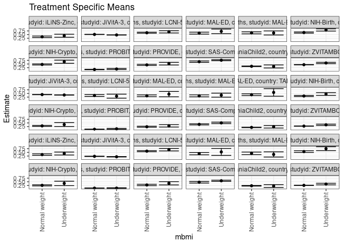

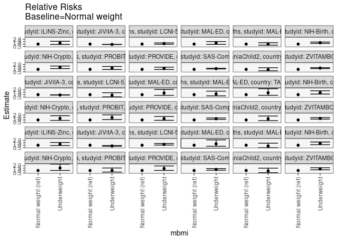

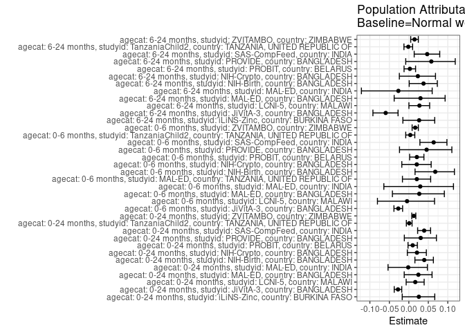

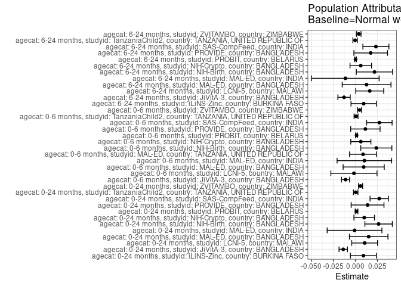

## Results Table

### Parameter: TSM

| agecat | studyid | country | intervention_level | baseline_level | estimate | ci_lower | ci_upper |
| --- | --- | --- | --- | --- | --- | --- | --- |
| 0-24 months | iLiNS-Zinc | BURKINA FASO | Normal weight | NA | 0.3474848 | 0.2944027 | 0.4005668 |
| 0-24 months | iLiNS-Zinc | BURKINA FASO | Underweight | NA | 0.4190179 | 0.3143118 | 0.5237239 |
| 0-24 months | JiVitA-3 | BANGLADESH | Normal weight | NA | 0.5092979 | 0.4999312 | 0.5186647 |
| 0-24 months | JiVitA-3 | BANGLADESH | Underweight | NA | 0.4735973 | 0.4628236 | 0.4843710 |
| 0-24 months | LCNI-5 | MALAWI | Normal weight | NA | 0.6250997 | 0.5889972 | 0.6612021 |
| 0-24 months | LCNI-5 | MALAWI | Underweight | NA | 0.6858135 | 0.6092019 | 0.7624250 |
| 0-24 months | MAL-ED | BANGLADESH | Normal weight | NA | 0.5990991 | 0.5345045 | 0.6636937 |
| 0-24 months | MAL-ED | BANGLADESH | Underweight | NA | 0.7187500 | 0.5626637 | 0.8748363 |
| 0-24 months | MAL-ED | INDIA | Normal weight | NA | 0.6166796 | 0.5478409 | 0.6855183 |
| 0-24 months | MAL-ED | INDIA | Underweight | NA | 0.6103477 | 0.4713669 | 0.7493284 |
| 0-24 months | NIH-Birth | BANGLADESH | Normal weight | NA | 0.6382173 | 0.5969678 | 0.6794668 |
| 0-24 months | NIH-Birth | BANGLADESH | Underweight | NA | 0.8158518 | 0.7405870 | 0.8911165 |
| 0-24 months | NIH-Crypto | BANGLADESH | Normal weight | NA | 0.4694696 | 0.4319223 | 0.5070170 |
| 0-24 months | NIH-Crypto | BANGLADESH | Underweight | NA | 0.6575411 | 0.5472837 | 0.7677986 |
| 0-24 months | PROBIT | BELARUS | Normal weight | NA | 0.1272187 | 0.1107050 | 0.1437324 |
| 0-24 months | PROBIT | BELARUS | Underweight | NA | 0.1584725 | 0.1201699 | 0.1967752 |
| 0-24 months | PROVIDE | BANGLADESH | Normal weight | NA | 0.4390974 | 0.3973268 | 0.4808681 |
| 0-24 months | PROVIDE | BANGLADESH | Underweight | NA | 0.5232499 | 0.4319902 | 0.6145095 |
| 0-24 months | SAS-CompFeed | INDIA | Normal weight | NA | 0.6595328 | 0.6100312 | 0.7090344 |
| 0-24 months | SAS-CompFeed | INDIA | Underweight | NA | 0.7603591 | 0.7268675 | 0.7938507 |
| 0-24 months | TanzaniaChild2 | TANZANIA, UNITED REPUBLIC OF | Normal weight | NA | 0.3450694 | 0.3254881 | 0.3646507 |
| 0-24 months | TanzaniaChild2 | TANZANIA, UNITED REPUBLIC OF | Underweight | NA | 0.3320867 | 0.2284041 | 0.4357693 |
| 0-24 months | ZVITAMBO | ZIMBABWE | Normal weight | NA | 0.4530499 | 0.4429263 | 0.4631736 |
| 0-24 months | ZVITAMBO | ZIMBABWE | Underweight | NA | 0.5704042 | 0.5262174 | 0.6145911 |
| 0-6 months | JiVitA-3 | BANGLADESH | Normal weight | NA | 0.4242034 | 0.4152195 | 0.4331874 |
| 0-6 months | JiVitA-3 | BANGLADESH | Underweight | NA | 0.3950537 | 0.3848000 | 0.4053074 |
| 0-6 months | LCNI-5 | MALAWI | Normal weight | NA | 0.3595818 | 0.2964588 | 0.4227048 |
| 0-6 months | LCNI-5 | MALAWI | Underweight | NA | 0.3143808 | 0.1765649 | 0.4521967 |
| 0-6 months | MAL-ED | BANGLADESH | Normal weight | NA | 0.3409987 | 0.2786504 | 0.4033471 |
| 0-6 months | MAL-ED | BANGLADESH | Underweight | NA | 0.4535901 | 0.2731074 | 0.6340729 |
| 0-6 months | MAL-ED | INDIA | Normal weight | NA | 0.3369201 | 0.2699288 | 0.4039114 |
| 0-6 months | MAL-ED | INDIA | Underweight | NA | 0.3835942 | 0.2449844 | 0.5222039 |
| 0-6 months | MAL-ED | TANZANIA, UNITED REPUBLIC OF | Normal weight | NA | 0.4132231 | 0.3510620 | 0.4753843 |
| 0-6 months | MAL-ED | TANZANIA, UNITED REPUBLIC OF | Underweight | NA | 0.5714286 | 0.3116959 | 0.8311612 |
| 0-6 months | NIH-Birth | BANGLADESH | Normal weight | NA | 0.3260264 | 0.2858236 | 0.3662292 |
| 0-6 months | NIH-Birth | BANGLADESH | Underweight | NA | 0.4618595 | 0.3671009 | 0.5566182 |
| 0-6 months | NIH-Crypto | BANGLADESH | Normal weight | NA | 0.2971238 | 0.2626830 | 0.3315646 |
| 0-6 months | NIH-Crypto | BANGLADESH | Underweight | NA | 0.3866316 | 0.2544033 | 0.5188600 |
| 0-6 months | PROBIT | BELARUS | Normal weight | NA | 0.0642823 | 0.0535448 | 0.0750199 |
| 0-6 months | PROBIT | BELARUS | Underweight | NA | 0.0953432 | 0.0641483 | 0.1265381 |
| 0-6 months | PROVIDE | BANGLADESH | Normal weight | NA | 0.2368087 | 0.2010360 | 0.2725814 |
| 0-6 months | PROVIDE | BANGLADESH | Underweight | NA | 0.2986932 | 0.2173144 | 0.3800721 |
| 0-6 months | SAS-CompFeed | INDIA | Normal weight | NA | 0.3994343 | 0.3612456 | 0.4376230 |
| 0-6 months | SAS-CompFeed | INDIA | Underweight | NA | 0.5008667 | 0.4505542 | 0.5511793 |
| 0-6 months | TanzaniaChild2 | TANZANIA, UNITED REPUBLIC OF | Normal weight | NA | 0.1920243 | 0.1758027 | 0.2082459 |
| 0-6 months | TanzaniaChild2 | TANZANIA, UNITED REPUBLIC OF | Underweight | NA | 0.2368421 | 0.1492053 | 0.3244789 |
| 0-6 months | ZVITAMBO | ZIMBABWE | Normal weight | NA | 0.2821866 | 0.2730295 | 0.2913436 |
| 0-6 months | ZVITAMBO | ZIMBABWE | Underweight | NA | 0.3706333 | 0.3268079 | 0.4144587 |
| 6-24 months | iLiNS-Zinc | BURKINA FASO | Normal weight | NA | 0.3472210 | 0.2944613 | 0.3999807 |
| 6-24 months | iLiNS-Zinc | BURKINA FASO | Underweight | NA | 0.4211982 | 0.3206546 | 0.5217417 |
| 6-24 months | JiVitA-3 | BANGLADESH | Normal weight | NA | 0.2292085 | 0.2168975 | 0.2415195 |
| 6-24 months | JiVitA-3 | BANGLADESH | Underweight | NA | 0.1975328 | 0.1842906 | 0.2107751 |
| 6-24 months | LCNI-5 | MALAWI | Normal weight | NA | 0.5820730 | 0.5426132 | 0.6215327 |
| 6-24 months | LCNI-5 | MALAWI | Underweight | NA | 0.6824547 | 0.5988259 | 0.7660834 |
| 6-24 months | MAL-ED | BANGLADESH | Normal weight | NA | 0.4113475 | 0.3298675 | 0.4928275 |
| 6-24 months | MAL-ED | BANGLADESH | Underweight | NA | 0.5294118 | 0.2913884 | 0.7674352 |
| 6-24 months | MAL-ED | INDIA | Normal weight | NA | 0.4334149 | 0.3456849 | 0.5211449 |
| 6-24 months | MAL-ED | INDIA | Underweight | NA | 0.3583002 | 0.1810377 | 0.5355627 |
| 6-24 months | NIH-Birth | BANGLADESH | Normal weight | NA | 0.5522554 | 0.4954683 | 0.6090426 |
| 6-24 months | NIH-Birth | BANGLADESH | Underweight | NA | 0.7518744 | 0.6185489 | 0.8851998 |
| 6-24 months | NIH-Crypto | BANGLADESH | Normal weight | NA | 0.2567565 | 0.2169446 | 0.2965683 |
| 6-24 months | NIH-Crypto | BANGLADESH | Underweight | NA | 0.3918843 | 0.2424193 | 0.5413492 |
| 6-24 months | PROBIT | BELARUS | Normal weight | NA | 0.0671430 | 0.0544496 | 0.0798364 |
| 6-24 months | PROBIT | BELARUS | Underweight | NA | 0.0686276 | 0.0438151 | 0.0934401 |
| 6-24 months | PROVIDE | BANGLADESH | Normal weight | NA | 0.2830852 | 0.2378278 | 0.3283426 |
| 6-24 months | PROVIDE | BANGLADESH | Underweight | NA | 0.3980562 | 0.2855208 | 0.5105917 |
| 6-24 months | SAS-CompFeed | INDIA | Normal weight | NA | 0.4706689 | 0.4158704 | 0.5254673 |
| 6-24 months | SAS-CompFeed | INDIA | Underweight | NA | 0.5706759 | 0.5297057 | 0.6116462 |
| 6-24 months | TanzaniaChild2 | TANZANIA, UNITED REPUBLIC OF | Normal weight | NA | 0.2283312 | 0.2071921 | 0.2494702 |
| 6-24 months | TanzaniaChild2 | TANZANIA, UNITED REPUBLIC OF | Underweight | NA | 0.2083333 | 0.1089524 | 0.3077142 |
| 6-24 months | ZVITAMBO | ZIMBABWE | Normal weight | NA | 0.2576802 | 0.2467664 | 0.2685941 |
| 6-24 months | ZVITAMBO | ZIMBABWE | Underweight | NA | 0.3446570 | 0.2913977 | 0.3979163 |

### Parameter: E(Y)

| agecat | studyid | country | intervention_level | baseline_level | estimate | ci_lower | ci_upper |
| --- | --- | --- | --- | --- | --- | --- | --- |
| 0-24 months | iLiNS-Zinc | BURKINA FASO | NA | NA | 0.3566542 | 0.3069876 | 0.4063208 |
| 0-24 months | JiVitA-3 | BANGLADESH | NA | NA | 0.4955174 | 0.4876719 | 0.5033630 |
| 0-24 months | LCNI-5 | MALAWI | NA | NA | 0.6356033 | 0.6029802 | 0.6682264 |
| 0-24 months | MAL-ED | BANGLADESH | NA | NA | 0.6141732 | 0.5541901 | 0.6741564 |
| 0-24 months | MAL-ED | INDIA | NA | NA | 0.6157025 | 0.5542897 | 0.6771153 |
| 0-24 months | NIH-Birth | BANGLADESH | NA | NA | 0.6645469 | 0.6276196 | 0.7014742 |
| 0-24 months | NIH-Crypto | BANGLADESH | NA | NA | 0.4794702 | 0.4438115 | 0.5151289 |
| 0-24 months | PROBIT | BELARUS | NA | NA | 0.1284965 | 0.1123633 | 0.1446297 |
| 0-24 months | PROVIDE | BANGLADESH | NA | NA | 0.4529148 | 0.4151667 | 0.4906629 |
| 0-24 months | SAS-CompFeed | INDIA | NA | NA | 0.6865672 | 0.6433613 | 0.7297731 |
| 0-24 months | TanzaniaChild2 | TANZANIA, UNITED REPUBLIC OF | NA | NA | 0.3454158 | 0.3261661 | 0.3646654 |
| 0-24 months | ZVITAMBO | ZIMBABWE | NA | NA | 0.4589062 | 0.4490494 | 0.4687630 |
| 0-6 months | JiVitA-3 | BANGLADESH | NA | NA | 0.4130330 | 0.4055721 | 0.4204940 |
| 0-6 months | LCNI-5 | MALAWI | NA | NA | 0.3579336 | 0.3007518 | 0.4151153 |
| 0-6 months | MAL-ED | BANGLADESH | NA | NA | 0.3503937 | 0.2916054 | 0.4091820 |
| 0-6 months | MAL-ED | INDIA | NA | NA | 0.3471074 | 0.2870050 | 0.4072099 |
| 0-6 months | MAL-ED | TANZANIA, UNITED REPUBLIC OF | NA | NA | 0.4218750 | 0.3612599 | 0.4824901 |
| 0-6 months | NIH-Birth | BANGLADESH | NA | NA | 0.3497615 | 0.3124631 | 0.3870600 |
| 0-6 months | NIH-Crypto | BANGLADESH | NA | NA | 0.3033113 | 0.2704998 | 0.3361228 |
| 0-6 months | PROBIT | BELARUS | NA | NA | 0.0656323 | 0.0549927 | 0.0762719 |
| 0-6 months | PROVIDE | BANGLADESH | NA | NA | 0.2481315 | 0.2153770 | 0.2808861 |
| 0-6 months | SAS-CompFeed | INDIA | NA | NA | 0.4266382 | 0.3925570 | 0.4607194 |
| 0-6 months | TanzaniaChild2 | TANZANIA, UNITED REPUBLIC OF | NA | NA | 0.1927505 | 0.1767818 | 0.2087193 |
| 0-6 months | ZVITAMBO | ZIMBABWE | NA | NA | 0.2869086 | 0.2779566 | 0.2958607 |
| 6-24 months | iLiNS-Zinc | BURKINA FASO | NA | NA | 0.3566542 | 0.3069876 | 0.4063208 |
| 6-24 months | JiVitA-3 | BANGLADESH | NA | NA | 0.2163480 | 0.2069669 | 0.2257290 |
| 6-24 months | LCNI-5 | MALAWI | NA | NA | 0.5983494 | 0.5626894 | 0.6340094 |
| 6-24 months | MAL-ED | BANGLADESH | NA | NA | 0.4240506 | 0.3467471 | 0.5013542 |
| 6-24 months | MAL-ED | INDIA | NA | NA | 0.4220779 | 0.3438191 | 0.5003367 |
| 6-24 months | NIH-Birth | BANGLADESH | NA | NA | 0.5739130 | 0.5216565 | 0.6261696 |
| 6-24 months | NIH-Crypto | BANGLADESH | NA | NA | 0.2628458 | 0.2244546 | 0.3012371 |
| 6-24 months | PROBIT | BELARUS | NA | NA | 0.0673219 | 0.0549549 | 0.0796890 |
| 6-24 months | PROVIDE | BANGLADESH | NA | NA | 0.3004386 | 0.2583143 | 0.3425629 |
| 6-24 months | SAS-CompFeed | INDIA | NA | NA | 0.4939435 | 0.4498186 | 0.5380683 |
| 6-24 months | TanzaniaChild2 | TANZANIA, UNITED REPUBLIC OF | NA | NA | 0.2280255 | 0.2072654 | 0.2487856 |
| 6-24 months | ZVITAMBO | ZIMBABWE | NA | NA | 0.2615147 | 0.2508057 | 0.2722237 |

### Parameter: RR

| agecat | studyid | country | intervention_level | baseline_level | estimate | ci_lower | ci_upper |
| --- | --- | --- | --- | --- | --- | --- | --- |
| 0-24 months | iLiNS-Zinc | BURKINA FASO | Normal weight | Normal weight | 1.0000000 | 1.0000000 | 1.0000000 |
| 0-24 months | iLiNS-Zinc | BURKINA FASO | Underweight | Normal weight | 1.2058598 | 0.9234418 | 1.5746500 |
| 0-24 months | JiVitA-3 | BANGLADESH | Normal weight | Normal weight | 1.0000000 | 1.0000000 | 1.0000000 |
| 0-24 months | JiVitA-3 | BANGLADESH | Underweight | Normal weight | 0.9299023 | 0.9063160 | 0.9541024 |
| 0-24 months | LCNI-5 | MALAWI | Normal weight | Normal weight | 1.0000000 | 1.0000000 | 1.0000000 |
| 0-24 months | LCNI-5 | MALAWI | Underweight | Normal weight | 1.0971266 | 0.9674768 | 1.2441506 |
| 0-24 months | MAL-ED | BANGLADESH | Normal weight | Normal weight | 1.0000000 | 1.0000000 | 1.0000000 |
| 0-24 months | MAL-ED | BANGLADESH | Underweight | Normal weight | 1.1997180 | 0.9414164 | 1.5288914 |
| 0-24 months | MAL-ED | INDIA | Normal weight | Normal weight | 1.0000000 | 1.0000000 | 1.0000000 |
| 0-24 months | MAL-ED | INDIA | Underweight | Normal weight | 0.9897322 | 0.7679120 | 1.2756277 |
| 0-24 months | NIH-Birth | BANGLADESH | Normal weight | Normal weight | 1.0000000 | 1.0000000 | 1.0000000 |
| 0-24 months | NIH-Birth | BANGLADESH | Underweight | Normal weight | 1.2783291 | 1.1414709 | 1.4315962 |
| 0-24 months | NIH-Crypto | BANGLADESH | Normal weight | Normal weight | 1.0000000 | 1.0000000 | 1.0000000 |
| 0-24 months | NIH-Crypto | BANGLADESH | Underweight | Normal weight | 1.4006042 | 1.1629179 | 1.6868707 |
| 0-24 months | PROBIT | BELARUS | Normal weight | Normal weight | 1.0000000 | 1.0000000 | 1.0000000 |
| 0-24 months | PROBIT | BELARUS | Underweight | Normal weight | 1.2456701 | 0.9748124 | 1.5917874 |
| 0-24 months | PROVIDE | BANGLADESH | Normal weight | Normal weight | 1.0000000 | 1.0000000 | 1.0000000 |
| 0-24 months | PROVIDE | BANGLADESH | Underweight | Normal weight | 1.1916487 | 0.9769394 | 1.4535462 |
| 0-24 months | SAS-CompFeed | INDIA | Normal weight | Normal weight | 1.0000000 | 1.0000000 | 1.0000000 |
| 0-24 months | SAS-CompFeed | INDIA | Underweight | Normal weight | 1.1528753 | 1.0840953 | 1.2260190 |
| 0-24 months | TanzaniaChild2 | TANZANIA, UNITED REPUBLIC OF | Normal weight | Normal weight | 1.0000000 | 1.0000000 | 1.0000000 |
| 0-24 months | TanzaniaChild2 | TANZANIA, UNITED REPUBLIC OF | Underweight | Normal weight | 0.9623767 | 0.7006731 | 1.3218273 |
| 0-24 months | ZVITAMBO | ZIMBABWE | Normal weight | Normal weight | 1.0000000 | 1.0000000 | 1.0000000 |
| 0-24 months | ZVITAMBO | ZIMBABWE | Underweight | Normal weight | 1.2590316 | 1.1615189 | 1.3647308 |
| 0-6 months | JiVitA-3 | BANGLADESH | Normal weight | Normal weight | 1.0000000 | 1.0000000 | 1.0000000 |
| 0-6 months | JiVitA-3 | BANGLADESH | Underweight | Normal weight | 0.9312836 | 0.9040754 | 0.9593106 |
| 0-6 months | LCNI-5 | MALAWI | Normal weight | Normal weight | 1.0000000 | 1.0000000 | 1.0000000 |
| 0-6 months | LCNI-5 | MALAWI | Underweight | Normal weight | 0.8742957 | 0.5447981 | 1.4030759 |
| 0-6 months | MAL-ED | BANGLADESH | Normal weight | Normal weight | 1.0000000 | 1.0000000 | 1.0000000 |
| 0-6 months | MAL-ED | BANGLADESH | Underweight | Normal weight | 1.3301813 | 0.8589784 | 2.0598684 |
| 0-6 months | MAL-ED | INDIA | Normal weight | Normal weight | 1.0000000 | 1.0000000 | 1.0000000 |
| 0-6 months | MAL-ED | INDIA | Underweight | Normal weight | 1.1385315 | 0.7535517 | 1.7201925 |
| 0-6 months | MAL-ED | TANZANIA, UNITED REPUBLIC OF | Normal weight | Normal weight | 1.0000000 | 1.0000000 | 1.0000000 |
| 0-6 months | MAL-ED | TANZANIA, UNITED REPUBLIC OF | Underweight | Normal weight | 1.3828571 | 0.8567351 | 2.2320714 |
| 0-6 months | NIH-Birth | BANGLADESH | Normal weight | Normal weight | 1.0000000 | 1.0000000 | 1.0000000 |
| 0-6 months | NIH-Birth | BANGLADESH | Underweight | Normal weight | 1.4166323 | 1.1156241 | 1.7988560 |
| 0-6 months | NIH-Crypto | BANGLADESH | Normal weight | Normal weight | 1.0000000 | 1.0000000 | 1.0000000 |
| 0-6 months | NIH-Crypto | BANGLADESH | Underweight | Normal weight | 1.3012474 | 0.9065766 | 1.8677350 |
| 0-6 months | PROBIT | BELARUS | Normal weight | Normal weight | 1.0000000 | 1.0000000 | 1.0000000 |
| 0-6 months | PROBIT | BELARUS | Underweight | Normal weight | 1.4831943 | 1.0764238 | 2.0436795 |
| 0-6 months | PROVIDE | BANGLADESH | Normal weight | Normal weight | 1.0000000 | 1.0000000 | 1.0000000 |
| 0-6 months | PROVIDE | BANGLADESH | Underweight | Normal weight | 1.2613269 | 0.9241478 | 1.7215274 |
| 0-6 months | SAS-CompFeed | INDIA | Normal weight | Normal weight | 1.0000000 | 1.0000000 | 1.0000000 |
| 0-6 months | SAS-CompFeed | INDIA | Underweight | Normal weight | 1.2539404 | 1.1150473 | 1.4101343 |
| 0-6 months | TanzaniaChild2 | TANZANIA, UNITED REPUBLIC OF | Normal weight | Normal weight | 1.0000000 | 1.0000000 | 1.0000000 |
| 0-6 months | TanzaniaChild2 | TANZANIA, UNITED REPUBLIC OF | Underweight | Normal weight | 1.2333967 | 0.8438583 | 1.8027521 |
| 0-6 months | ZVITAMBO | ZIMBABWE | Normal weight | Normal weight | 1.0000000 | 1.0000000 | 1.0000000 |
| 0-6 months | ZVITAMBO | ZIMBABWE | Underweight | Normal weight | 1.3134336 | 1.1618704 | 1.4847679 |
| 6-24 months | iLiNS-Zinc | BURKINA FASO | Normal weight | Normal weight | 1.0000000 | 1.0000000 | 1.0000000 |
| 6-24 months | iLiNS-Zinc | BURKINA FASO | Underweight | Normal weight | 1.2130549 | 0.9361302 | 1.5718991 |
| 6-24 months | JiVitA-3 | BANGLADESH | Normal weight | Normal weight | 1.0000000 | 1.0000000 | 1.0000000 |
| 6-24 months | JiVitA-3 | BANGLADESH | Underweight | Normal weight | 0.8618040 | 0.7932082 | 0.9363319 |
| 6-24 months | LCNI-5 | MALAWI | Normal weight | Normal weight | 1.0000000 | 1.0000000 | 1.0000000 |
| 6-24 months | LCNI-5 | MALAWI | Underweight | Normal weight | 1.1724555 | 1.0192104 | 1.3487421 |
| 6-24 months | MAL-ED | BANGLADESH | Normal weight | Normal weight | 1.0000000 | 1.0000000 | 1.0000000 |
| 6-24 months | MAL-ED | BANGLADESH | Underweight | Normal weight | 1.2870183 | 0.7874368 | 2.1035542 |
| 6-24 months | MAL-ED | INDIA | Normal weight | Normal weight | 1.0000000 | 1.0000000 | 1.0000000 |
| 6-24 months | MAL-ED | INDIA | Underweight | Normal weight | 0.8266910 | 0.4842483 | 1.4112966 |
| 6-24 months | NIH-Birth | BANGLADESH | Normal weight | Normal weight | 1.0000000 | 1.0000000 | 1.0000000 |
| 6-24 months | NIH-Birth | BANGLADESH | Underweight | Normal weight | 1.3614613 | 1.1093065 | 1.6709330 |
| 6-24 months | NIH-Crypto | BANGLADESH | Normal weight | Normal weight | 1.0000000 | 1.0000000 | 1.0000000 |
| 6-24 months | NIH-Crypto | BANGLADESH | Underweight | Normal weight | 1.5262877 | 1.0115652 | 2.3029205 |
| 6-24 months | PROBIT | BELARUS | Normal weight | Normal weight | 1.0000000 | 1.0000000 | 1.0000000 |
| 6-24 months | PROBIT | BELARUS | Underweight | Normal weight | 1.0221114 | 0.6872426 | 1.5201499 |
| 6-24 months | PROVIDE | BANGLADESH | Normal weight | Normal weight | 1.0000000 | 1.0000000 | 1.0000000 |
| 6-24 months | PROVIDE | BANGLADESH | Underweight | Normal weight | 1.4061356 | 1.0183559 | 1.9415780 |
| 6-24 months | SAS-CompFeed | INDIA | Normal weight | Normal weight | 1.0000000 | 1.0000000 | 1.0000000 |
| 6-24 months | SAS-CompFeed | INDIA | Underweight | Normal weight | 1.2124786 | 1.0519652 | 1.3974839 |
| 6-24 months | TanzaniaChild2 | TANZANIA, UNITED REPUBLIC OF | Normal weight | Normal weight | 1.0000000 | 1.0000000 | 1.0000000 |
| 6-24 months | TanzaniaChild2 | TANZANIA, UNITED REPUBLIC OF | Underweight | Normal weight | 0.9124174 | 0.5612510 | 1.4833032 |
| 6-24 months | ZVITAMBO | ZIMBABWE | Normal weight | Normal weight | 1.0000000 | 1.0000000 | 1.0000000 |
| 6-24 months | ZVITAMBO | ZIMBABWE | Underweight | Normal weight | 1.3375377 | 1.1396526 | 1.5697829 |

### Parameter: PAR

| agecat | studyid | country | intervention_level | baseline_level | estimate | ci_lower | ci_upper |
| --- | --- | --- | --- | --- | --- | --- | --- |
| 0-24 months | iLiNS-Zinc | BURKINA FASO | Normal weight | NA | 0.0091695 | -0.0055606 | 0.0238996 |
| 0-24 months | JiVitA-3 | BANGLADESH | Normal weight | NA | -0.0137805 | -0.0185795 | -0.0089815 |
| 0-24 months | LCNI-5 | MALAWI | Normal weight | NA | 0.0105037 | -0.0041444 | 0.0251517 |
| 0-24 months | MAL-ED | BANGLADESH | Normal weight | NA | 0.0150741 | -0.0067628 | 0.0369110 |
| 0-24 months | MAL-ED | INDIA | Normal weight | NA | -0.0009771 | -0.0320597 | 0.0301054 |
| 0-24 months | NIH-Birth | BANGLADESH | Normal weight | NA | 0.0263296 | 0.0107540 | 0.0419052 |
| 0-24 months | NIH-Crypto | BANGLADESH | Normal weight | NA | 0.0100006 | -0.0016821 | 0.0216832 |
| 0-24 months | PROBIT | BELARUS | Normal weight | NA | 0.0012778 | -0.0002210 | 0.0027767 |
| 0-24 months | PROVIDE | BANGLADESH | Normal weight | NA | 0.0138174 | -0.0048152 | 0.0324499 |
| 0-24 months | SAS-CompFeed | INDIA | Normal weight | NA | 0.0270343 | 0.0166016 | 0.0374671 |
| 0-24 months | TanzaniaChild2 | TANZANIA, UNITED REPUBLIC OF | Normal weight | NA | 0.0003464 | -0.0021873 | 0.0028801 |
| 0-24 months | ZVITAMBO | ZIMBABWE | Normal weight | NA | 0.0058563 | 0.0034827 | 0.0082298 |
| 0-6 months | JiVitA-3 | BANGLADESH | Normal weight | NA | -0.0111704 | -0.0157700 | -0.0065708 |
| 0-6 months | LCNI-5 | MALAWI | Normal weight | NA | -0.0016482 | -0.0278599 | 0.0245636 |
| 0-6 months | MAL-ED | BANGLADESH | Normal weight | NA | 0.0093950 | -0.0139586 | 0.0327486 |
| 0-6 months | MAL-ED | INDIA | Normal weight | NA | 0.0101873 | -0.0207866 | 0.0411612 |
| 0-6 months | MAL-ED | TANZANIA, UNITED REPUBLIC OF | Normal weight | NA | 0.0086519 | -0.0066061 | 0.0239098 |
| 0-6 months | NIH-Birth | BANGLADESH | Normal weight | NA | 0.0237351 | 0.0060890 | 0.0413813 |
| 0-6 months | NIH-Crypto | BANGLADESH | Normal weight | NA | 0.0061874 | -0.0052421 | 0.0176170 |
| 0-6 months | PROBIT | BELARUS | Normal weight | NA | 0.0013500 | 0.0001733 | 0.0025266 |
| 0-6 months | PROVIDE | BANGLADESH | Normal weight | NA | 0.0113228 | -0.0053655 | 0.0280111 |
| 0-6 months | SAS-CompFeed | INDIA | Normal weight | NA | 0.0272039 | 0.0127724 | 0.0416355 |
| 0-6 months | TanzaniaChild2 | TANZANIA, UNITED REPUBLIC OF | Normal weight | NA | 0.0007263 | -0.0015136 | 0.0029661 |
| 0-6 months | ZVITAMBO | ZIMBABWE | Normal weight | NA | 0.0047221 | 0.0024296 | 0.0070146 |
| 6-24 months | iLiNS-Zinc | BURKINA FASO | Normal weight | NA | 0.0094332 | -0.0049896 | 0.0238560 |
| 6-24 months | JiVitA-3 | BANGLADESH | Normal weight | NA | -0.0128605 | -0.0198752 | -0.0058459 |
| 6-24 months | LCNI-5 | MALAWI | Normal weight | NA | 0.0162764 | 0.0004104 | 0.0321425 |
| 6-24 months | MAL-ED | BANGLADESH | Normal weight | NA | 0.0127031 | -0.0149643 | 0.0403705 |
| 6-24 months | MAL-ED | INDIA | Normal weight | NA | -0.0113370 | -0.0496068 | 0.0269328 |
| 6-24 months | NIH-Birth | BANGLADESH | Normal weight | NA | 0.0216576 | 0.0011063 | 0.0422089 |
| 6-24 months | NIH-Crypto | BANGLADESH | Normal weight | NA | 0.0060894 | -0.0061084 | 0.0182872 |
| 6-24 months | PROBIT | BELARUS | Normal weight | NA | 0.0001790 | -0.0008068 | 0.0011648 |
| 6-24 months | PROVIDE | BANGLADESH | Normal weight | NA | 0.0173534 | -0.0017097 | 0.0364164 |
| 6-24 months | SAS-CompFeed | INDIA | Normal weight | NA | 0.0232746 | 0.0084988 | 0.0380504 |
| 6-24 months | TanzaniaChild2 | TANZANIA, UNITED REPUBLIC OF | Normal weight | NA | -0.0003057 | -0.0028487 | 0.0022373 |
| 6-24 months | ZVITAMBO | ZIMBABWE | Normal weight | NA | 0.0038344 | 0.0012768 | 0.0063921 |

### Parameter: PAF

| agecat | studyid | country | intervention_level | baseline_level | estimate | ci_lower | ci_upper |
| --- | --- | --- | --- | --- | --- | --- | --- |
| 0-24 months | iLiNS-Zinc | BURKINA FASO | Normal weight | NA | 0.0257097 | -0.0169801 | 0.0666075 |
| 0-24 months | JiVitA-3 | BANGLADESH | Normal weight | NA | -0.0278103 | -0.0375323 | -0.0181794 |
| 0-24 months | LCNI-5 | MALAWI | Normal weight | NA | 0.0165255 | -0.0068307 | 0.0393399 |
| 0-24 months | MAL-ED | BANGLADESH | Normal weight | NA | 0.0245438 | -0.0118432 | 0.0596222 |
| 0-24 months | MAL-ED | INDIA | Normal weight | NA | -0.0015870 | -0.0533642 | 0.0476451 |
| 0-24 months | NIH-Birth | BANGLADESH | Normal weight | NA | 0.0396204 | 0.0156030 | 0.0630518 |
| 0-24 months | NIH-Crypto | BANGLADESH | Normal weight | NA | 0.0208575 | -0.0038678 | 0.0449739 |
| 0-24 months | PROBIT | BELARUS | Normal weight | NA | 0.0099443 | -0.0021181 | 0.0218616 |
| 0-24 months | PROVIDE | BANGLADESH | Normal weight | NA | 0.0305076 | -0.0115473 | 0.0708141 |
| 0-24 months | SAS-CompFeed | INDIA | Normal weight | NA | 0.0393761 | 0.0225967 | 0.0558675 |
| 0-24 months | TanzaniaChild2 | TANZANIA, UNITED REPUBLIC OF | Normal weight | NA | 0.0010028 | -0.0063632 | 0.0083150 |
| 0-24 months | ZVITAMBO | ZIMBABWE | Normal weight | NA | 0.0127613 | 0.0075701 | 0.0179255 |
| 0-6 months | JiVitA-3 | BANGLADESH | Normal weight | NA | -0.0270448 | -0.0382244 | -0.0159857 |
| 0-6 months | LCNI-5 | MALAWI | Normal weight | NA | -0.0046048 | -0.0805673 | 0.0660177 |
| 0-6 months | MAL-ED | BANGLADESH | Normal weight | NA | 0.0268126 | -0.0421346 | 0.0911983 |
| 0-6 months | MAL-ED | INDIA | Normal weight | NA | 0.0293492 | -0.0641486 | 0.1146322 |
| 0-6 months | MAL-ED | TANZANIA, UNITED REPUBLIC OF | Normal weight | NA | 0.0205081 | -0.0163884 | 0.0560652 |
| 0-6 months | NIH-Birth | BANGLADESH | Normal weight | NA | 0.0678609 | 0.0159717 | 0.1170140 |
| 0-6 months | NIH-Crypto | BANGLADESH | Normal weight | NA | 0.0203996 | -0.0180199 | 0.0573692 |
| 0-6 months | PROBIT | BELARUS | Normal weight | NA | 0.0205686 | 0.0020686 | 0.0387257 |
| 0-6 months | PROVIDE | BANGLADESH | Normal weight | NA | 0.0456323 | -0.0239156 | 0.1104564 |
| 0-6 months | SAS-CompFeed | INDIA | Normal weight | NA | 0.0637634 | 0.0284558 | 0.0977879 |
| 0-6 months | TanzaniaChild2 | TANZANIA, UNITED REPUBLIC OF | Normal weight | NA | 0.0037679 | -0.0079388 | 0.0153386 |
| 0-6 months | ZVITAMBO | ZIMBABWE | Normal weight | NA | 0.0164585 | 0.0084384 | 0.0244138 |
| 6-24 months | iLiNS-Zinc | BURKINA FASO | Normal weight | NA | 0.0264492 | -0.0153056 | 0.0664868 |
| 6-24 months | JiVitA-3 | BANGLADESH | Normal weight | NA | -0.0594437 | -0.0921833 | -0.0276855 |
| 6-24 months | LCNI-5 | MALAWI | Normal weight | NA | 0.0272022 | 0.0002208 | 0.0534555 |
| 6-24 months | MAL-ED | BANGLADESH | Normal weight | NA | 0.0299566 | -0.0376377 | 0.0931477 |
| 6-24 months | MAL-ED | INDIA | Normal weight | NA | -0.0268599 | -0.1217051 | 0.0599657 |
| 6-24 months | NIH-Birth | BANGLADESH | Normal weight | NA | 0.0377367 | 0.0009640 | 0.0731560 |
| 6-24 months | NIH-Crypto | BANGLADESH | Normal weight | NA | 0.0231671 | -0.0243462 | 0.0684765 |
| 6-24 months | PROBIT | BELARUS | Normal weight | NA | 0.0026584 | -0.0122465 | 0.0173438 |
| 6-24 months | PROVIDE | BANGLADESH | Normal weight | NA | 0.0577601 | -0.0079451 | 0.1191821 |
| 6-24 months | SAS-CompFeed | INDIA | Normal weight | NA | 0.0471200 | 0.0137729 | 0.0793395 |
| 6-24 months | TanzaniaChild2 | TANZANIA, UNITED REPUBLIC OF | Normal weight | NA | -0.0013406 | -0.0125449 | 0.0097397 |
| 6-24 months | ZVITAMBO | ZIMBABWE | Normal weight | NA | 0.0146624 | 0.0048384 | 0.0243895 |